# Lab Exercise Week 5 and Homework 2

Your Name Here

October 1, 2019

## Requirements

1. Do the following exercises, answer Q1 to Q13, and present your answers in a HTML file generated by RMarkdown. Specifically, the RMarkdown file of this document is provided as a template and starting point, so just finish this document by typing up your answers after each question, and format your answers appropriately. Note that the answers for the first 3 questions are given as an example.
2. Do exericses ISLR 3.7 Problem 1, 3 and 4. Type up your answers at the end of this document. No need to transcribe the problem descriptions, just clearly label your answers to match with the problem number.

## Build a Multiple Linear Regression Model and Assess its Performance

First, load the *MASS* package that contains the Boston dataset. The Boston data set is loaded with package, use `?Boston` to learn about the meanings of each column.

```r
library(MASS)
```

- **Q1**: In the Boston data set, what is the Total Sum of Squares (TSS) of the median house value *medv*?

```r
 (TSS <- sum((Boston$medv - mean(Boston$medv))^2))
```

```
[1] 42716.3
```

Fit *medv* (median house value) as a linear function of *lstat* (percentage of lower status of the population) and *age* (proportion of units built prior to 1940).

```r
lm.fit <- lm(medv ~ lstat + age, data = Boston)
```

From the model summary, answer these questions:

- **Q2**: What is the Residual Sum of Squares (RSS) of this fit?

```r
(RSS <- (nrow(Boston)-2-1)*(summary(lm.fit)$sigma)^2)
```

```
[1] 19168.13
```

- **Q3**: How much proportion of the variance in *medv* is accounted for by this fit?

```r
summary(lm.fit)$r.sq
```

```
[1] 0.5512689
```

- **Q4**: Overall, is there a relationship between the response variable *medv* and the predictors *lstat* and *age*? How do you make such a conclusion?

```r
summary(lm.fit)
```

```
Call:
lm(formula = medv ~ lstat + age, data = Boston)

Residuals:
    Min      1Q  Median      3Q     Max
-15.981  -3.978  -1.283   1.968  23.158

Coefficients:
            Estimate Std. Error t value Pr(>|t|)
(Intercept) 33.22276    0.73085  45.458  < 2e-16 ***
lstat       -1.03207    0.04819 -21.416  < 2e-16 ***
age          0.03454    0.01223   2.826  0.00491 **
---
Signif. codes:  0 '***' 0.001 '**' 0.01 '*' 0.05 '.' 0.1 ' ' 1

Residual standard error: 6.173 on 503 degrees of freedom
Multiple R-squared:  0.5513,    Adjusted R-squared:  0.5495
F-statistic:   309 on 2 and 503 DF,  p-value: < 2.2e-16
```

There is a relationship. The `lstat` has more predictive power then `age` becauase of low enougth *p-value* `< 2.2e-16` for `lstat` variable: ~55% of variance in *medv* that is explained by the model.

- **Q5**: Is there a relationship between *medv* and each of the predictors? How do you tell?

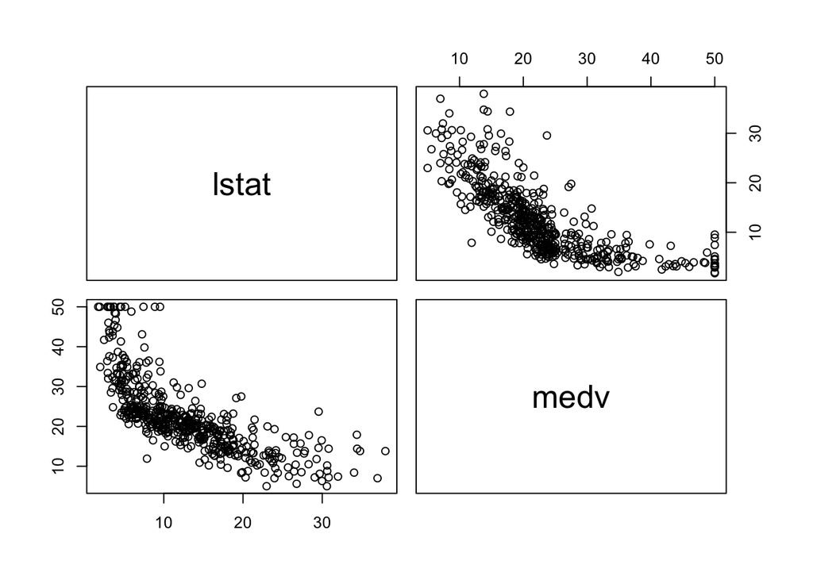

```r
pairs(~ lstat + medv, Boston)
```

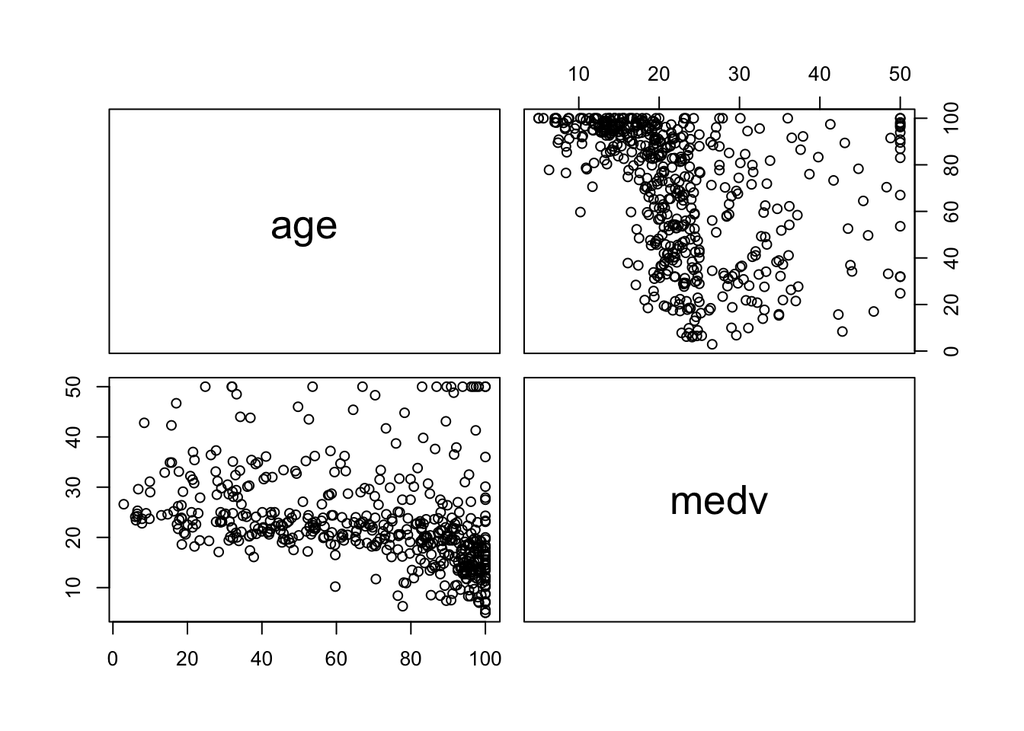

```r
pairs(~ age + medv, Boston)
```

There is a *nonlinear* function exists that fits relationships between `lstat` and `medv` but `age` has less obvious dependency `medv`.

- **Q6**: What is the estimated standard deviation of the irreducible error in the model $\text{medv} = \beta_0 + \beta_1 \cdot \text{lstat} + \beta_2 \cdot \text{age} + \epsilon$.

```r
#Residual standard error: 6.173 on 503 degrees of freedom
summary(lm.fit)$sigma
```

```
[1] 6.173136
```

- **Q7**: How do you interpret the coefficient estimate on *age*, i.e., the value

```r
format(coef(lm.fit)['age'], digits=3)
```

```
     age
"0.0345"
```

, in the model context? It means that $\ \beta_2 = 0.0345$

in the full model equasion will be:

$\text{medv} = 33.22276 + -1.03207 \cdot \text{lstat} + 0.0345 \cdot \text{age} + \epsilon$

## Build a Full Model and Compute VIFs

Let’s first check if all columns of the data set are numeric hence can be used as predictors.

```r
sapply(Boston, mode)
```

```
     crim        zn     indus      chas       nox        rm       age
"numeric" "numeric" "numeric" "numeric" "numeric" "numeric" "numeric"
      dis       rad       tax   ptratio     black     lstat      medv
"numeric" "numeric" "numeric" "numeric" "numeric" "numeric" "numeric"
```

Are all columns of the numeric type?

```r
all(sapply(Boston, mode) == "numeric")
```

```
[1] TRUE
```

. Let’s try using all columns (except for *medv*, of course) as predictors and fit a full model.

```r
lm.fit.full <- lm(medv ~ ., data = Boston)
```

Now display the model summary using

```r
summary(lm.fit.full)
```

```
Call:
lm(formula = medv ~ ., data = Boston)

Residuals:
    Min      1Q  Median      3Q     Max
-15.595  -2.730  -0.518   1.777  26.199

Coefficients:
              Estimate Std. Error t value Pr(>|t|)
(Intercept)  3.646e+01  5.103e+00   7.144 3.28e-12 ***
crim        -1.080e-01  3.286e-02  -3.287 0.001087 **
zn           4.642e-02  1.373e-02   3.382 0.000778 ***
indus        2.056e-02  6.150e-02   0.334 0.738288
chas         2.687e+00  8.616e-01   3.118 0.001925 **
nox         -1.777e+01  3.820e+00  -4.651 4.25e-06 ***
rm           3.810e+00  4.179e-01   9.116  < 2e-16 ***
age          6.922e-04  1.321e-02   0.052 0.958229
dis         -1.476e+00  1.995e-01  -7.398 6.01e-13 ***
rad          3.060e-01  6.635e-02   4.613 5.07e-06 ***
tax         -1.233e-02  3.760e-03  -3.280 0.001112 **
ptratio     -9.527e-01  1.308e-01  -7.283 1.31e-12 ***
black        9.312e-03  2.686e-03   3.467 0.000573 ***
lstat       -5.248e-01  5.072e-02 -10.347  < 2e-16 ***
---
Signif. codes:  0 '***' 0.001 '**' 0.01 '*' 0.05 '.' 0.1 ' ' 1

Residual standard error: 4.745 on 492 degrees of freedom
Multiple R-squared:  0.7406,    Adjusted R-squared:  0.7338
F-statistic: 108.1 on 13 and 492 DF,  p-value: < 2.2e-16
```

and answewr these questions.

- **Q8**: How many predictors are used in this model fit? *13* predictors.
- **Q9**: Which predictors have a significant effect on the response variable at a confidence level of 0.95?

*All* except:

- `indus 2.056e-02 6.150e-02 0.334 0.738288`
- `age 6.922e-04 1.321e-02 0.052 0.958229`
- **Q10**: Does *age* present a significant effect on *medv* in this model?

Clearly *not*!

Let’s calculate the Variance Inflation Factor (VIF) of each predictor in the above full model. VIF of a predictor $X_j$ measures how well $X_j$ can be represented as a linear combination of other predictors used in the model. A high VIF indicates that the predictor has a high multicollinearity with other predictors, thus should probably be excluded from the set of predictors to improve the model fit. VIF of a predictor $X_j$ is calculated by the formula $\text{VIF}_j = \frac{1}{1-R_j^2}$, where $R_j^2$ is the R-Square value of the model fit by using $X_j$ as the response variable and all other predictors used in the original model as predictors. For instance, to calculate the VIF of *age* in the context of `lm.fit.full` model:

```r
(VIF_age <- 1/(1-summary(lm(age ~ .-medv, data = Boston))$r.sq))
```

```
[1] 3.100826
```

Note that in the above line, `lm(age ~ .-medv, data=Boston)` means to fit a linear model for *age* using all columns of `Boston` but `medv`.

We can use the `vif` function in the `car` package to calculate the VIF for all predictors in a model, as follows.

```r
#install.packages("car")  # run this line if you have not installed the "car" package before
library(car)
vif(lm.fit.full)
```

```
    crim       zn    indus     chas      nox       rm      age      dis
1.792192 2.298758 3.991596 1.073995 4.393720 1.933744 3.100826 3.955945
     rad      tax  ptratio    black    lstat
7.484496 9.008554 1.799084 1.348521 2.941491
```

## Model Selection

Now, let’s exclude *age* from the full model and fit again.

```r
lm.fit.all_but_age <- lm(medv ~ . - age, data = Boston)
```

Display the

```r
summary(lm.fit.all_but_age)
```

```
Call:
lm(formula = medv ~ . - age, data = Boston)

Residuals:
     Min       1Q   Median       3Q      Max
-15.6054  -2.7313  -0.5188   1.7601  26.2243

Coefficients:
              Estimate Std. Error t value Pr(>|t|)
(Intercept)  36.436927   5.080119   7.172 2.72e-12 ***
crim         -0.108006   0.032832  -3.290 0.001075 **
zn            0.046334   0.013613   3.404 0.000719 ***
indus         0.020562   0.061433   0.335 0.737989
chas          2.689026   0.859598   3.128 0.001863 **
nox         -17.713540   3.679308  -4.814 1.97e-06 ***
rm            3.814394   0.408480   9.338  < 2e-16 ***
dis          -1.478612   0.190611  -7.757 5.03e-14 ***
rad           0.305786   0.066089   4.627 4.75e-06 ***
tax          -0.012329   0.003755  -3.283 0.001099 **
ptratio      -0.952211   0.130294  -7.308 1.10e-12 ***
black         0.009321   0.002678   3.481 0.000544 ***
lstat        -0.523852   0.047625 -10.999  < 2e-16 ***
---
Signif. codes:  0 '***' 0.001 '**' 0.01 '*' 0.05 '.' 0.1 ' ' 1

Residual standard error: 4.74 on 493 degrees of freedom
Multiple R-squared:  0.7406,    Adjusted R-squared:  0.7343
F-statistic: 117.3 on 12 and 493 DF,  p-value: < 2.2e-16
```

and answer these questions.

- **Q11**: Compare the Multiple R-squared and Adjusted R-sqaured values between this model and the full model. Comment on the differences. Which model do you think is better?

`Multiple R-squared: 0.7406, Adjusted R-squared: 0.7343` - All but `age` `Multiple R-squared: 0.7406, Adjusted R-squared: 0.7338` - Including `age`

*Higher Adjusted R-squared* of the *All but* `age` model suggests its supperiority.

- **Q12**: Compute the AIC and BIC of the model `lm.fit.full` and `lm.fit.all_but_age`, respectively. Use the function `AIC(lm.fit.full)` and `BIC(lm.fit.full)`. Compare the two models in terms of AIC and BIC. Does the conclusion consistent with what you get in Q11?

```r
library(knitr)
rc = data.frame(
(c('Model', 'AIC', 'BIC')),
(c('Full', AIC(lm.fit.full), BIC(lm.fit.full))),
(c('-Age',AIC(lm.fit.all_but_age),BIC(lm.fit.all_but_age)))
)
kable(rc)
```

| X.c..Model….AIC….BIC… | X.c..Full…AIC.lm.fit.full…BIC.lm.fit.full… | X.c…Age…AIC.lm.fit.all_but_age…BIC.lm.fit.all_but_age… |
| --- | --- | --- |
| Model | Full | -Age |
| AIC | 3027.60859407555 | 3025.61141822068 |
| BIC | 3091.00664411486 | 3084.7829315907 |

*Lower* `AIC` and `BIC` for `lm.fit.all_but_age` supports the current idea of `lm.fit.all_but_age` model being better.

- **Q13**: Pick a termination criteria (i.e., Adj. R-squared, AIC or BIC) and carry out the Backward Selection procedure to find the best fit.

```r
#library(tidyverse)
library(caret)
library(leaps)
step.model <- stepAIC(lm.fit.all_but_age, direction = "backward")
```

```
Start:  AIC=1587.65
medv ~ (crim + zn + indus + chas + nox + rm + age + dis + rad +
    tax + ptratio + black + lstat) - age

          Df Sum of Sq   RSS    AIC
- indus    1      2.52 11081 1585.8
<none>                 11079 1587.7
- chas     1    219.91 11299 1595.6
- tax      1    242.24 11321 1596.6
- crim     1    243.20 11322 1596.6
- zn       1    260.32 11339 1597.4
- black    1    272.26 11351 1597.9
- rad      1    481.09 11560 1607.2
- nox      1    520.87 11600 1608.9
- ptratio  1   1200.23 12279 1637.7
- dis      1   1352.26 12431 1643.9
- rm       1   1959.55 13038 1668.0
- lstat    1   2718.88 13798 1696.7

Step:  AIC=1585.76
medv ~ crim + zn + chas + nox + rm + dis + rad + tax + ptratio +
    black + lstat

          Df Sum of Sq   RSS    AIC
<none>                 11081 1585.8
- chas     1    227.21 11309 1594.0
- crim     1    245.37 11327 1594.8
- zn       1    257.82 11339 1595.4
- black    1    270.82 11352 1596.0
- tax      1    273.62 11355 1596.1
- rad      1    500.92 11582 1606.1
- nox      1    541.91 11623 1607.9
- ptratio  1   1206.45 12288 1636.0
- dis      1   1448.94 12530 1645.9
- rm       1   1963.66 13045 1666.3
- lstat    1   2723.48 13805 1695.0
```

```r
summary(step.model)
```

```
Call:
lm(formula = medv ~ crim + zn + chas + nox + rm + dis + rad +
    tax + ptratio + black + lstat, data = Boston)

Residuals:
     Min       1Q   Median       3Q      Max
-15.5984  -2.7386  -0.5046   1.7273  26.2373

Coefficients:
              Estimate Std. Error t value Pr(>|t|)
(Intercept)  36.341145   5.067492   7.171 2.73e-12 ***
crim         -0.108413   0.032779  -3.307 0.001010 **
zn            0.045845   0.013523   3.390 0.000754 ***
chas          2.718716   0.854240   3.183 0.001551 **
nox         -17.376023   3.535243  -4.915 1.21e-06 ***
rm            3.801579   0.406316   9.356  < 2e-16 ***
dis          -1.492711   0.185731  -8.037 6.84e-15 ***
rad           0.299608   0.063402   4.726 3.00e-06 ***
tax          -0.011778   0.003372  -3.493 0.000521 ***
ptratio      -0.946525   0.129066  -7.334 9.24e-13 ***
black         0.009291   0.002674   3.475 0.000557 ***
lstat        -0.522553   0.047424 -11.019  < 2e-16 ***
---
Signif. codes:  0 '***' 0.001 '**' 0.01 '*' 0.05 '.' 0.1 ' ' 1

Residual standard error: 4.736 on 494 degrees of freedom
Multiple R-squared:  0.7406,    Adjusted R-squared:  0.7348
F-statistic: 128.2 on 11 and 494 DF,  p-value: < 2.2e-16
```

Another way with limiting number of predictors:

```r
# Set up repeated k-fold cross-validation
train.control <- trainControl(method = "cv", number = 5)
# Train the model
step.model11 <- train(medv ~ . - age, data = Boston,
                    method = "leapBackward",
                    tuneGrid = data.frame(nvmax = 1:12),
                    trControl = train.control
                    )
step.model11$results
```

```
   nvmax     RMSE  Rsquared      MAE    RMSESD RsquaredSD     MAESD
1      1 6.691823 0.4952349 4.765057 1.0229688 0.12603245 0.3535444
2      2 5.638484 0.6433317 4.041734 0.6043663 0.06545017 0.3364592
3      3 5.329944 0.6793371 3.764466 0.8122665 0.08832179 0.3901958
4      4 5.298488 0.6845664 3.733406 0.6866451 0.08250698 0.3038863
5      5 5.152205 0.6961319 3.641762 0.7380384 0.08677891 0.2441713
6      6 5.180207 0.6944591 3.595742 0.8212731 0.09510162 0.3180292
7      7 5.203240 0.6915914 3.634016 0.7574220 0.08721090 0.3360129
8      8 5.189760 0.6946618 3.639939 0.7463032 0.08520242 0.3258036
9      9 5.147965 0.6984385 3.604566 0.7478572 0.08382519 0.3117799
10    10 5.080567 0.7061372 3.543926 0.7295840 0.08422776 0.2977200
11    11 4.973203 0.7168614 3.482443 0.7233124 0.08279139 0.2800076
12    12 4.975197 0.7164430 3.484910 0.7285913 0.08355520 0.2855434
```

```r
summary(step.model11)
```

```
Subset selection object
12 Variables  (and intercept)
        Forced in Forced out
crim        FALSE      FALSE
zn          FALSE      FALSE
indus       FALSE      FALSE
chas        FALSE      FALSE
nox         FALSE      FALSE
rm          FALSE      FALSE
dis         FALSE      FALSE
rad         FALSE      FALSE
tax         FALSE      FALSE
ptratio     FALSE      FALSE
black       FALSE      FALSE
lstat       FALSE      FALSE
1 subsets of each size up to 11
Selection Algorithm: backward
          crim zn  indus chas nox rm  dis rad tax ptratio black lstat
1  ( 1 )  " "  " " " "   " "  " " " " " " " " " " " "     " "   "*"
2  ( 1 )  " "  " " " "   " "  " " "*" " " " " " " " "     " "   "*"
3  ( 1 )  " "  " " " "   " "  " " "*" " " " " " " "*"     " "   "*"
4  ( 1 )  " "  " " " "   " "  " " "*" "*" " " " " "*"     " "   "*"
5  ( 1 )  " "  " " " "   " "  "*" "*" "*" " " " " "*"     " "   "*"
6  ( 1 )  " "  " " " "   " "  "*" "*" "*" " " " " "*"     "*"   "*"
7  ( 1 )  " "  " " " "   " "  "*" "*" "*" "*" " " "*"     "*"   "*"
8  ( 1 )  "*"  " " " "   " "  "*" "*" "*" "*" " " "*"     "*"   "*"
9  ( 1 )  "*"  " " " "   " "  "*" "*" "*" "*" "*" "*"     "*"   "*"
10  ( 1 ) "*"  "*" " "   " "  "*" "*" "*" "*" "*" "*"     "*"   "*"
11  ( 1 ) "*"  "*" " "   "*"  "*" "*" "*" "*" "*" "*"     "*"   "*"
```

```r
step.model11$bestTune
```

```
   nvmax
11    11
```

## ISLR Exercises (Section 3.7)

### Problem 1:

The table 3.4 shows valuse of *p-value* for varaibles. The Hypothesis is that sales has *zero* dependency movey spent on ads on *TV*, *radio*, and *newspaper*. The *lower* then $10^{-3}$ *p-value* says otherwise: spending the budget on ads in *TV* and *radio* impacts sales, but not so much for buyng the ads in *newspepers*.

### Problem 3:

The model equation:

$\text{salary} = \hat{\beta}_0 + \hat{\beta}_1 \cdot \text{GPA} + \hat{\beta}_2 \cdot \text{IQ} + \hat{\beta}_3 \cdot \text{Gender } + \hat{\beta}_4 \cdot (\text{IQ} \cdot \text{GPA}) + \hat{\beta}_5 \cdot (\text{GPA} \cdot \text{Gender})$

Where $\hat{\beta}_0 = 50$ $\hat{\beta}_1 = 20$ $\hat{\beta}_2 = 0.07$ $\hat{\beta}_3 = 35$ $\hat{\beta}_4 = 0.01$ $\hat{\beta}_5 = -10$

#### a)

Let’s plug the numbers into *Numbers*

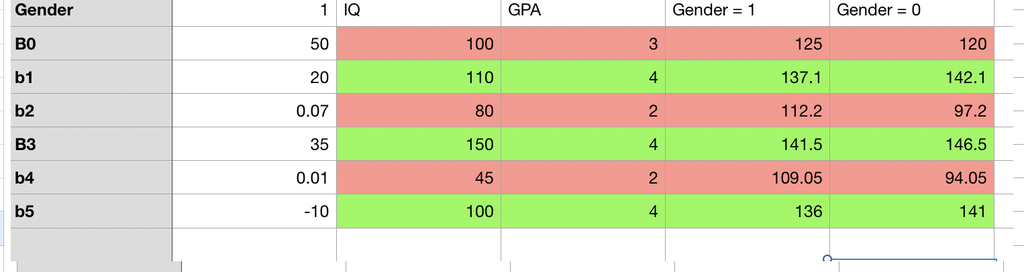

Calculations

##### i.

NO

##### ii.

NO

##### iii.

NO - It depends! From the quick check we can see that when IQ and GPA reach certain points the Male salaries becomes higher

##### iv.

NO - Same as n *iii.*

#### b)

*137.10*

#### c)

False: The Interaction Effect is there. The scale of it is small but not negligebale. Let’s transform the model to hightlight the interaction between *IQ* and *GPA*:

$\text{salary} = \hat{\beta}_0 + \hat{\beta}_1 \text{GPA} + \hat{\beta}_3 \cdot \text{Gender } + (\hat{\beta}_2 + \hat{\beta}_4 \cdot \text{GPA}) \cdot \text{IQ} \cdot + \hat{\beta}_5 \cdot (\text{GPA} \cdot \text{Gender})$

The increase of *GPA* by one adds a ~ *1%* of itself to the acceleration of the grow of the *IQ*.

### Problem 4:

#### a)

The training *RSS* for *polynomial* regression model will be *smaller* then *RSS* for *linear* regression model: greater flexibility allows to find closer fit.

#### b)

The testing *RSS* for *polynomial* regression model may be *greater* then testing *RSS* for *linear* regression model: greater flexibility may yeild residuals where there must be none cause the true fit is linear.

#### c)

The training *RSS* for *polynomial* regression model will be *smaller* then *RSS* for *linear* regression model.

#### d)

The testing *RSS* for *polynomial* regression model will be *smaller* then testing *RSS* for *linear* regression model: greater flexibility will minimize residuals cause the true fit is *non-linear* in the test data.